# Pan_YinTa

There is a solid Exploratory Data Analysis from Rounak Banik [link](https://www.kaggle.com/rounakbanik/ted-data-analysis/notebook). Therefore, in this assignment we will focus on how to use text analytics to further provide insights to the data. Strongly recommending to read the exploratory data analysis from Rounak Banik before start to read the notebook.

Questions about what makes a TED talk popular?

1. The popularity of speaker
2. The duration of speeches
3. The theme should be interesting

```python
import numpy as np
import pandas as pd
import matplotlib.pyplot as plt
import seaborn as sns
```

```python
plt.style.use('ggplot')
```

```python
ted_main = pd.read_csv("ted_main.csv")
print ted_main.shape
ted_main.head()
```

```
(2550, 17)
```

|  | comments | description | duration | event | film_date | languages | main_speaker | name | num_speaker | published_date | ratings | related_talks | speaker_occupation | tags | title | url | views |
| --- | --- | --- | --- | --- | --- | --- | --- | --- | --- | --- | --- | --- | --- | --- | --- | --- | --- |
| 0 | 4553 | Sir Ken Robinson makes an entertaining and pro... | 1164 | TED2006 | 1140825600 | 60 | Ken Robinson | Ken Robinson: Do schools kill creativity? | 1 | 1151367060 | [{'id': 7, 'name': 'Funny', 'count': 19645}, {... | [{'id': 865, 'hero': 'https://pe.tedcdn.com/im... | Author/educator | ['children', 'creativity', 'culture', 'dance',... | Do schools kill creativity? | https://www.ted.com/talks/ken_robinson_says_sc... | 47227110 |
| 1 | 265 | With the same humor and humanity he exuded in ... | 977 | TED2006 | 1140825600 | 43 | Al Gore | Al Gore: Averting the climate crisis | 1 | 1151367060 | [{'id': 7, 'name': 'Funny', 'count': 544}, {'i... | [{'id': 243, 'hero': 'https://pe.tedcdn.com/im... | Climate advocate | ['alternative energy', 'cars', 'climate change... | Averting the climate crisis | https://www.ted.com/talks/al_gore_on_averting_... | 3200520 |
| 2 | 124 | New York Times columnist David Pogue takes aim... | 1286 | TED2006 | 1140739200 | 26 | David Pogue | David Pogue: Simplicity sells | 1 | 1151367060 | [{'id': 7, 'name': 'Funny', 'count': 964}, {'i... | [{'id': 1725, 'hero': 'https://pe.tedcdn.com/i... | Technology columnist | ['computers', 'entertainment', 'interface desi... | Simplicity sells | https://www.ted.com/talks/david_pogue_says_sim... | 1636292 |
| 3 | 200 | In an emotionally charged talk, MacArthur-winn... | 1116 | TED2006 | 1140912000 | 35 | Majora Carter | Majora Carter: Greening the ghetto | 1 | 1151367060 | [{'id': 3, 'name': 'Courageous', 'count': 760}... | [{'id': 1041, 'hero': 'https://pe.tedcdn.com/i... | Activist for environmental justice | ['MacArthur grant', 'activism', 'business', 'c... | Greening the ghetto | https://www.ted.com/talks/majora_carter_s_tale... | 1697550 |
| 4 | 593 | You've never seen data presented like this. Wi... | 1190 | TED2006 | 1140566400 | 48 | Hans Rosling | Hans Rosling: The best stats you've ever seen | 1 | 1151440680 | [{'id': 9, 'name': 'Ingenious', 'count': 3202}... | [{'id': 2056, 'hero': 'https://pe.tedcdn.com/i... | Global health expert; data visionary | ['Africa', 'Asia', 'Google', 'demo', 'economic... | The best stats you've ever seen | https://www.ted.com/talks/hans_rosling_shows_t... | 12005869 |

```python
import datetime
ted_main['film_date'] = ted_main['film_date'].apply(lambda x: datetime.datetime.fromtimestamp( int(x)).strftime('%Y-%m-%d'))
ted_main['published_date'] = ted_main['published_date'].apply(lambda x: datetime.datetime.fromtimestamp( int(x)).strftime('%Y-%m-%d'))
ted_main.head()
```

|  | comments | description | duration | event | film_date | languages | main_speaker | name | num_speaker | published_date | ratings | related_talks | speaker_occupation | tags | title | url | views |
| --- | --- | --- | --- | --- | --- | --- | --- | --- | --- | --- | --- | --- | --- | --- | --- | --- | --- |
| 0 | 4553 | Sir Ken Robinson makes an entertaining and pro... | 1164 | TED2006 | 2006-02-24 | 60 | Ken Robinson | Ken Robinson: Do schools kill creativity? | 1 | 2006-06-26 | [{'id': 7, 'name': 'Funny', 'count': 19645}, {... | [{'id': 865, 'hero': 'https://pe.tedcdn.com/im... | Author/educator | ['children', 'creativity', 'culture', 'dance',... | Do schools kill creativity? | https://www.ted.com/talks/ken_robinson_says_sc... | 47227110 |
| 1 | 265 | With the same humor and humanity he exuded in ... | 977 | TED2006 | 2006-02-24 | 43 | Al Gore | Al Gore: Averting the climate crisis | 1 | 2006-06-26 | [{'id': 7, 'name': 'Funny', 'count': 544}, {'i... | [{'id': 243, 'hero': 'https://pe.tedcdn.com/im... | Climate advocate | ['alternative energy', 'cars', 'climate change... | Averting the climate crisis | https://www.ted.com/talks/al_gore_on_averting_... | 3200520 |
| 2 | 124 | New York Times columnist David Pogue takes aim... | 1286 | TED2006 | 2006-02-23 | 26 | David Pogue | David Pogue: Simplicity sells | 1 | 2006-06-26 | [{'id': 7, 'name': 'Funny', 'count': 964}, {'i... | [{'id': 1725, 'hero': 'https://pe.tedcdn.com/i... | Technology columnist | ['computers', 'entertainment', 'interface desi... | Simplicity sells | https://www.ted.com/talks/david_pogue_says_sim... | 1636292 |
| 3 | 200 | In an emotionally charged talk, MacArthur-winn... | 1116 | TED2006 | 2006-02-25 | 35 | Majora Carter | Majora Carter: Greening the ghetto | 1 | 2006-06-26 | [{'id': 3, 'name': 'Courageous', 'count': 760}... | [{'id': 1041, 'hero': 'https://pe.tedcdn.com/i... | Activist for environmental justice | ['MacArthur grant', 'activism', 'business', 'c... | Greening the ghetto | https://www.ted.com/talks/majora_carter_s_tale... | 1697550 |
| 4 | 593 | You've never seen data presented like this. Wi... | 1190 | TED2006 | 2006-02-21 | 48 | Hans Rosling | Hans Rosling: The best stats you've ever seen | 1 | 2006-06-27 | [{'id': 9, 'name': 'Ingenious', 'count': 3202}... | [{'id': 2056, 'hero': 'https://pe.tedcdn.com/i... | Global health expert; data visionary | ['Africa', 'Asia', 'Google', 'demo', 'economic... | The best stats you've ever seen | https://www.ted.com/talks/hans_rosling_shows_t... | 12005869 |

```python
transcript = pd.read_csv("transcripts.csv")
print transcript.shape
transcript.head()
```

```
(2467, 2)
```

|  | transcript | url |
| --- | --- | --- |
| 0 | Good morning. How are you?(Laughter)It's been ... | https://www.ted.com/talks/ken_robinson_says_sc... |
| 1 | Thank you so much, Chris. And it's truly a gre... | https://www.ted.com/talks/al_gore_on_averting_... |
| 2 | (Music: "The Sound of Silence," Simon & Garfun... | https://www.ted.com/talks/david_pogue_says_sim... |
| 3 | If you're here today — and I'm very happy that... | https://www.ted.com/talks/majora_carter_s_tale... |
| 4 | About 10 years ago, I took on the task to teac... | https://www.ted.com/talks/hans_rosling_shows_t... |

```python
url_main = ted_main.url.unique()
url_transcript = transcript.url.unique()
```

```python
print len(url_main)
print len(url_transcript)
```

```
2550
2464
```

```python
# All the url in transcript can be matched back to main
# There are 86 speeches do not have transcripts -> drop them
print len(set(url_transcript) - set(url_main))
print len(set(url_main) - set(url_transcript))
```

```
0
86
```

```python
# It seems like there are some ratings in different aspects
print ted_main.iloc[0,]["ratings"]
print ""
print ted_main.iloc[1,]["ratings"]
```

```
[{'id': 7, 'name': 'Funny', 'count': 19645}, {'id': 1, 'name': 'Beautiful', 'count': 4573}, {'id': 9, 'name': 'Ingenious', 'count': 6073}, {'id': 3, 'name': 'Courageous', 'count': 3253}, {'id': 11, 'name': 'Longwinded', 'count': 387}, {'id': 2, 'name': 'Confusing', 'count': 242}, {'id': 8, 'name': '…

[{'id': 7, 'name': 'Funny', 'count': 544}, {'id': 3, 'name': 'Courageous', 'count': 139}, {'id': 2, 'name': 'Confusing', 'count': 62}, {'id': 1, 'name': 'Beautiful', 'count': 58}, {'id': 21, 'name': 'Unconvincing', 'count': 258}, {'id': 11, 'name': 'Longwinded', 'count': 113}, {'id': 8, 'name': 'Inf…
```

```python
print ted_main.iloc[0,]['tags']
print ""
print ted_main.iloc[0,]['tags']
```

```
['children', 'creativity', 'culture', 'dance', 'education', 'parenting', 'teaching']

['children', 'creativity', 'culture', 'dance', 'education', 'parenting', 'teaching']
```

```python
import ast
```

```python
ted_main['tags'] = ted_main['tags'].apply(lambda x: ast.literal_eval(x))
ted_main['ratings'] = ted_main['ratings'].apply(lambda x: ast.literal_eval(x))
```

```python
taglist = [item for sublist in ted_main['tags'].tolist() for item in sublist]
```

```python
from collections import Counter
stat = Counter(taglist)
```

```python
# There are about 416 different tags for TED -> how to simplify it?
# We should organize the tags through text analysis
stat = pd.Series(stat)
print stat.shape
stat.nlargest(20)
```

```
(416,)
```

```
technology       727
science          567
global issues    501
culture          486
TEDx             450
design           418
business         348
entertainment    299
health           236
innovation       229
society          224
art              221
social change    218
future           195
communication    191
biology          189
creativity       189
humanity         182
collaboration    174
environment      165
dtype: int64
```

```python
rating_name = [dic['name'] for sublist in ted_main['ratings'].tolist() for dic in sublist]
```

```python
# There are 14 aspects of rating
# It could be flatted
print len(set(rating_name))
print set(rating_name)
```

```
14
set(['Beautiful', 'Funny', 'Inspiring', 'Obnoxious', 'OK', 'Fascinating', 'Informative', 'Persuasive', 'Longwinded', 'Ingenious', 'Jaw-dropping', 'Unconvincing', 'Courageous', 'Confusing'])
```

```python
# All the videos have 14 aspects
np.mean(ted_main['ratings'].apply(lambda x: len(x)))
```

```
14.0
```

```python
def new_dic(x):
    new_dic = {}
    for row in x:
        new_dic[row['name']] = row['count']
    return new_dic
```

```python
ted_main['new_rating'] = ted_main['ratings'].map(new_dic)
```

```python
for name in set(rating_name):
    ted_main[name] = ted_main['new_rating'].map(lambda x:x[name])
ted_main.head()
```

|  | comments | description | duration | event | film_date | languages | main_speaker | name | num_speaker | published_date | ... | OK | Fascinating | Informative | Persuasive | Longwinded | Ingenious | Jaw-dropping | Unconvincing | Courageous | Confusing |
| --- | --- | --- | --- | --- | --- | --- | --- | --- | --- | --- | --- | --- | --- | --- | --- | --- | --- | --- | --- | --- | --- |
| 0 | 4553 | Sir Ken Robinson makes an entertaining and pro... | 1164 | TED2006 | 2006-02-24 | 60 | Ken Robinson | Ken Robinson: Do schools kill creativity? | 1 | 2006-06-26 | ... | 1174 | 10581 | 7346 | 10704 | 387 | 6073 | 4439 | 300 | 3253 | 242 |
| 1 | 265 | With the same humor and humanity he exuded in ... | 977 | TED2006 | 2006-02-24 | 43 | Al Gore | Al Gore: Averting the climate crisis | 1 | 2006-06-26 | ... | 203 | 132 | 443 | 268 | 113 | 56 | 116 | 258 | 139 | 62 |
| 2 | 124 | New York Times columnist David Pogue takes aim... | 1286 | TED2006 | 2006-02-23 | 26 | David Pogue | David Pogue: Simplicity sells | 1 | 2006-06-26 | ... | 146 | 166 | 395 | 230 | 78 | 183 | 54 | 104 | 45 | 27 |
| 3 | 200 | In an emotionally charged talk, MacArthur-winn... | 1116 | TED2006 | 2006-02-25 | 35 | Majora Carter | Majora Carter: Greening the ghetto | 1 | 2006-06-26 | ... | 85 | 132 | 380 | 460 | 53 | 105 | 230 | 36 | 760 | 32 |
| 4 | 593 | You've never seen data presented like this. Wi... | 1190 | TED2006 | 2006-02-21 | 48 | Hans Rosling | Hans Rosling: The best stats you've ever seen | 1 | 2006-06-27 | ... | 248 | 4606 | 5433 | 2542 | 110 | 3202 | 3736 | 67 | 318 | 72 |

5 rows × 32 columns

```python
ted_main.drop(['ratings','new_rating'],axis=1,inplace=True)
```

```python
ted_main['sum_rating'] = ted_main['Beautiful']+ted_main['Funny']+ted_main['Inspiring']+ted_main['Obnoxious']+ted_main['OK']+ted_main['Fascinating']+ted_main['Informative']+ted_main['Persuasive']+ted_main['Longwinded']+ted_main['Ingenious']+ted_main['Jaw-dropping']+ted_main['Unconvincing']+ted_main['Courageous']+ted_main['Confusing']
ted_main['sum_positive'] = ted_main['Beautiful']+ted_main['Funny']+ted_main['Inspiring']+ted_main['Fascinating']+ted_main['Informative']+ted_main['Ingenious']+ted_main['Courageous']
ted_main['sum_negative'] = ted_main['Obnoxious']+ted_main['Longwinded']+ted_main['Jaw-dropping']+ted_main['Unconvincing']+ted_main['Confusing']
```

```python
# sum_rating is highly correlated to sum_positive -> most people give positive rating
# sum_rating is also highly correlated to views
ted_main[['comments','views','sum_rating','sum_positive','sum_negative']].corr()
```

|  | comments | views | sum_rating | sum_positive | sum_negative |
| --- | --- | --- | --- | --- | --- |
| comments | 1.000000 | 0.530939 | 0.644329 | 0.617565 | 0.448210 |
| views | 0.530939 | 1.000000 | 0.865586 | 0.862166 | 0.509990 |
| sum_rating | 0.644329 | 0.865586 | 1.000000 | 0.991258 | 0.651521 |
| sum_positive | 0.617565 | 0.862166 | 0.991258 | 1.000000 | 0.565042 |
| sum_negative | 0.448210 | 0.509990 | 0.651521 | 0.565042 | 1.000000 |

```python
# Rating should be standarized
ted_main['Beautiful'] = ted_main['Beautiful']/ted_main['sum_rating']
ted_main['Funny'] = ted_main['Funny']/ted_main['sum_rating']
ted_main['Inspiring'] = ted_main['Inspiring']/ted_main['sum_rating']
ted_main['Obnoxious'] = ted_main['Obnoxious']/ted_main['sum_rating']
ted_main['OK'] = ted_main['OK']/ted_main['sum_rating']
ted_main['Fascinating'] = ted_main['Fascinating']/ted_main['sum_rating']
ted_main['Informative'] = ted_main['Informative']/ted_main['sum_rating']
ted_main['Persuasive'] = ted_main['Persuasive']/ted_main['sum_rating']
ted_main['Longwinded'] = ted_main['Longwinded']/ted_main['sum_rating']
ted_main['Ingenious'] = ted_main['Ingenious']/ted_main['sum_rating']
ted_main['Jaw-dropping'] = ted_main['Jaw-dropping']/ted_main['sum_rating']
ted_main['Unconvincing'] = ted_main['Unconvincing']/ted_main['sum_rating']
ted_main['Courageous'] = ted_main['Courageous']/ted_main['sum_rating']
ted_main['Confusing'] = ted_main['Confusing']/ted_main['sum_rating']
```

```python
ted_main['sum_positive'] = ted_main['sum_positive']/ted_main['sum_rating']
ted_main['sum_negative'] = ted_main['sum_negative']/ted_main['sum_rating']
```

```python
ted_main["sum_negative"].describe()
```

```
count    2550.000000
mean        0.124114
std         0.087973
min         0.008351
25%         0.063238
50%         0.098526
75%         0.157144
max         0.781688
Name: sum_negative, dtype: float64
```

```python
cols = list(set(rating_name))
cols.append("url")
cols.append("sum_rating")
cols.append("sum_negative")
ted_main[ted_main.sum_negative > 0.5][cols]
```

|  | Beautiful | Funny | Inspiring | Obnoxious | OK | Fascinating | Informative | Persuasive | Longwinded | Ingenious | Jaw-dropping | Unconvincing | Courageous | Confusing | url | sum_rating | sum_negative |
| --- | --- | --- | --- | --- | --- | --- | --- | --- | --- | --- | --- | --- | --- | --- | --- | --- | --- |
| 13 | 0.033305 | 0.012505 | 0.056631 | 0.002765 | 0.022604 | 0.110497 | 0.055429 | 0.009258 | 0.006613 | 0.121919 | 0.558254 | 0.003848 | 0.004088 | 0.002284 | https://www.ted.com/talks/jeff_han_demos_his_b... | 8317 | 0.573765 |
| 108 | 0.030465 | 0.003374 | 0.041311 | 0.001012 | 0.005736 | 0.078236 | 0.031188 | 0.004579 | 0.001928 | 0.083683 | 0.709954 | 0.001976 | 0.002892 | 0.003664 | https://www.ted.com/talks/blaise_aguera_y_arca... | 20745 | 0.718535 |
| 113 | 0.037037 | 0.010101 | 0.097643 | 0.063973 | 0.087542 | 0.040404 | 0.124579 | 0.013468 | 0.215488 | 0.037037 | 0.030303 | 0.202020 | 0.040404 | 0.000000 | https://www.ted.com/talks/david_rockwell_build... | 297 | 0.511785 |
| 481 | 0.022228 | 0.004763 | 0.069331 | 0.360148 | 0.033871 | 0.028314 | 0.018259 | 0.018523 | 0.118285 | 0.011379 | 0.004499 | 0.234189 | 0.011643 | 0.064567 | https://www.ted.com/talks/daniel_libeskind_s_1... | 3779 | 0.781688 |
| 494 | 0.010479 | 0.031587 | 0.041617 | 0.154341 | 0.005389 | 0.075449 | 0.055539 | 0.096707 | 0.003144 | 0.023204 | 0.026198 | 0.328443 | 0.068413 | 0.079491 | https://www.ted.com/talks/elaine_morgan_says_w... | 6680 | 0.591617 |
| 1704 | 0.008610 | 0.023985 | 0.012915 | 0.092251 | 0.049200 | 0.021525 | 0.171587 | 0.037515 | 0.059041 | 0.003690 | 0.007380 | 0.402829 | 0.046125 | 0.063346 | https://www.ted.com/talks/richard_ledgett_the_... | 1626 | 0.624846 |
| 1923 | 0.018721 | 0.023401 | 0.067083 | 0.234009 | 0.037441 | 0.039002 | 0.184087 | 0.088924 | 0.017161 | 0.007800 | 0.004680 | 0.145086 | 0.014041 | 0.118565 | https://www.ted.com/talks/romina_libster_the_p... | 641 | 0.519501 |
| 2314 | 0.084036 | 0.039730 | 0.125692 | 0.165663 | 0.009632 | 0.028654 | 0.026246 | 0.027450 | 0.028413 | 0.011317 | 0.012280 | 0.299302 | 0.106188 | 0.035396 | https://www.ted.com/talks/kelli_jean_drinkwate... | 4153 | 0.541055 |

```python
ted_main["sum_positive"].describe()
```

```
count    2550.000000
mean        0.743025
std         0.113057
min         0.165917
25%         0.678510
50%         0.760458
75%         0.829003
max         0.979434
Name: sum_positive, dtype: float64
```

## Popularity of Speaker

```python
Speaker_Sum = ted_main.groupby('main_speaker').size()
print Speaker_Sum.describe()
Speaker_Sum.nlargest(10)
```

```
count    2156.000000
mean        1.182746
std         0.574799
min         1.000000
25%         1.000000
50%         1.000000
75%         1.000000
max         9.000000
dtype: float64
```

```
main_speaker
Hans Rosling            9
Juan Enriquez           7
Marco Tempest           6
Rives                   6
Bill Gates              5
Clay Shirky             5
Dan Ariely              5
Jacqueline Novogratz    5
Julian Treasure         5
Nicholas Negroponte     5
dtype: int64
```

```python
print Speaker_Sum.shape
np.sum(Speaker_Sum > 1)
```

```
(2156,)
```

```
276
```

```python
Speaker_Sum2 = ted_main.groupby('main_speaker')[['views','comments','sum_rating','sum_positive','sum_negative']].mean()
Speaker_Sum2.head()
```

| main_speaker | views | comments | sum_rating | sum_positive | sum_negative |
| --- | --- | --- | --- | --- | --- |
| OK Go | 1.493866e+06 | 27.000000 | 1442.000000 | 0.807906 | 0.142164 |
| Rodrigo y Gabriela | 1.138566e+06 | 33.000000 | 1145.000000 | 0.730131 | 0.241921 |
| Silk Road Ensemble | 6.407340e+05 | 5.000000 | 161.000000 | 0.819876 | 0.118012 |
| Sofi Tukker | 8.156110e+05 | 8.000000 | 157.000000 | 0.796178 | 0.146497 |
| AJ Jacobs | 1.622793e+06 | 272.666667 | 2243.333333 | 0.728649 | 0.155404 |

```python
Speaker_Sum2 = pd.concat([Speaker_Sum2,Speaker_Sum],axis=1,join='inner')
Speaker_Sum2.head()
```

| main_speaker | views | comments | sum_rating | sum_positive | sum_negative | 0 |
| --- | --- | --- | --- | --- | --- | --- |
| OK Go | 1.493866e+06 | 27.000000 | 1442.000000 | 0.807906 | 0.142164 | 1 |
| Rodrigo y Gabriela | 1.138566e+06 | 33.000000 | 1145.000000 | 0.730131 | 0.241921 | 1 |
| Silk Road Ensemble | 6.407340e+05 | 5.000000 | 161.000000 | 0.819876 | 0.118012 | 1 |
| Sofi Tukker | 8.156110e+05 | 8.000000 | 157.000000 | 0.796178 | 0.146497 | 1 |
| AJ Jacobs | 1.622793e+06 | 272.666667 | 2243.333333 | 0.728649 | 0.155404 | 3 |

```python
Speaker_Sum2.describe()
```

|  | views | comments | sum_rating | sum_positive | sum_negative | 0 |
| --- | --- | --- | --- | --- | --- | --- |
| count | 2.156000e+03 | 2156.000000 | 2156.000000 | 2156.000000 | 2156.000000 | 2156.000000 |
| mean | 1.618160e+06 | 182.008098 | 2271.413159 | 0.744523 | 0.124041 | 1.182746 |
| std | 2.177624e+06 | 230.492001 | 3559.829535 | 0.110811 | 0.086110 | 0.574799 |
| min | 5.044300e+04 | 2.000000 | 68.000000 | 0.165917 | 0.008351 | 1.000000 |
| 25% | 7.609232e+05 | 64.000000 | 850.500000 | 0.679709 | 0.064133 | 1.000000 |
| 50% | 1.118156e+06 | 117.000000 | 1416.000000 | 0.761711 | 0.098518 | 1.000000 |
| 75% | 1.628674e+06 | 217.000000 | 2417.250000 | 0.829855 | 0.157468 | 1.000000 |
| max | 4.315540e+07 | 2877.000000 | 70665.000000 | 0.979434 | 0.781688 | 9.000000 |

```python
# Speaker with higher number of speeches
Speaker_Sum2.columns = [u'views', u'comments', u'sum_rating', u'sum_positive', u'sum_negative','Num']
Speaker_Sum2.sort_values(by='Num',ascending=False).head(10)
```

| main_speaker | views | comments | sum_rating | sum_positive | sum_negative | Num |
| --- | --- | --- | --- | --- | --- | --- |
| Hans Rosling | 3.063014e+06 | 342.777778 | 6995.666667 | 0.716086 | 0.123262 | 9 |
| Juan Enriquez | 1.794195e+06 | 197.714286 | 2825.571429 | 0.672918 | 0.157828 | 7 |
| Rives | 1.664777e+06 | 128.833333 | 2385.833333 | 0.830883 | 0.109745 | 6 |
| Marco Tempest | 2.226157e+06 | 158.500000 | 2944.000000 | 0.733267 | 0.198920 | 6 |
| Clay Shirky | 1.250086e+06 | 318.600000 | 2454.000000 | 0.684606 | 0.072846 | 5 |
| Nicholas Negroponte | 7.943818e+05 | 77.800000 | 898.800000 | 0.775587 | 0.119085 | 5 |
| Julian Treasure | 6.185532e+06 | 237.800000 | 6444.800000 | 0.724954 | 0.054581 | 5 |
| Dan Ariely | 3.147546e+06 | 238.000000 | 5434.800000 | 0.719146 | 0.065100 | 5 |
| Jacqueline Novogratz | 7.564852e+05 | 100.000000 | 1304.400000 | 0.764111 | 0.070761 | 5 |
| Bill Gates | 2.655084e+06 | 444.600000 | 2642.400000 | 0.645616 | 0.112964 | 5 |

```python
# Popular speeches, defined by views
Speaker_Sum2.sort_values(by='views',ascending=False).head(10)
```

| main_speaker | views | comments | sum_rating | sum_positive | sum_negative | Num |
| --- | --- | --- | --- | --- | --- | --- |
| Amy Cuddy | 43155405.0 | 2290.0 | 65968.0 | 0.818745 | 0.069898 | 1 |
| Mary Roach | 22270883.0 | 354.0 | 11273.0 | 0.832077 | 0.095627 | 1 |
| Jill Bolte Taylor | 21190883.0 | 2877.0 | 70665.0 | 0.796264 | 0.170622 | 1 |
| Tony Robbins | 20685401.0 | 672.0 | 15356.0 | 0.685400 | 0.128093 | 1 |
| Simon Sinek | 20556685.0 | 1112.0 | 36673.5 | 0.803845 | 0.048393 | 2 |
| Cameron Russell | 19787465.0 | 846.0 | 8620.0 | 0.796752 | 0.074594 | 1 |
| Brené Brown | 19578522.0 | 1317.0 | 37360.5 | 0.883450 | 0.046880 | 2 |
| Dan Pink | 18830983.0 | 1094.0 | 22615.0 | 0.706345 | 0.061021 | 1 |
| Susan Cain | 17629275.0 | 1155.0 | 30037.0 | 0.841895 | 0.030462 | 1 |
| Pamela Meyer | 16861578.0 | 561.0 | 9943.0 | 0.733079 | 0.085387 | 1 |

```python
# Popular speeches, defined by comments
# Some poor speeches could also lead to high number of comments. People like to critize them!
Speaker_Sum2.sort_values(by='comments',ascending=False).head(10)
```

| main_speaker | views | comments | sum_rating | sum_positive | sum_negative | Num |
| --- | --- | --- | --- | --- | --- | --- |
| Jill Bolte Taylor | 2.119088e+07 | 2877.0 | 70665.000000 | 0.796264 | 0.170622 | 1 |
| David Chalmers | 2.162764e+06 | 2673.0 | 2756.000000 | 0.657112 | 0.198476 | 1 |
| Janet Echelman | 1.832930e+06 | 2492.0 | 4158.000000 | 0.853535 | 0.117605 | 1 |
| Richard Dawkins | 2.526405e+06 | 2348.0 | 6861.333333 | 0.690047 | 0.170107 | 3 |
| Amy Cuddy | 4.315540e+07 | 2290.0 | 65968.000000 | 0.818745 | 0.069898 | 1 |
| Michael Specter | 1.838628e+06 | 2272.0 | 5629.000000 | 0.505951 | 0.216202 | 1 |
| Sam Harris | 3.012999e+06 | 1923.0 | 5983.000000 | 0.636195 | 0.136396 | 2 |
| Ken Robinson | 1.575157e+07 | 1723.5 | 33564.750000 | 0.794474 | 0.056469 | 4 |
| Eric X. Li | 2.449736e+06 | 1640.0 | 4105.000000 | 0.682095 | 0.133009 | 1 |
| Steve Jobs | 8.744428e+06 | 1627.0 | 38158.000000 | 0.838802 | 0.070287 | 1 |

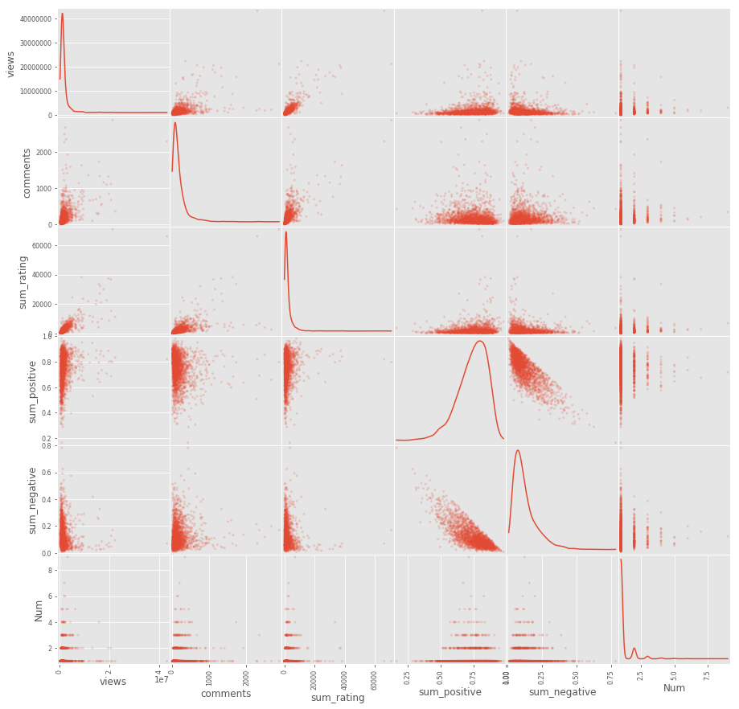

```python
from pandas.plotting import scatter_matrix
scatter_matrix(Speaker_Sum2, alpha=0.2, figsize=(15, 15), diagonal='kde')
plt.show()
```

From the plot above, we can see:

1. Views could be positive correlated to number of comments, number of rating, percentage of positive rating.
2. Views could be negative correlated to percentage of negative rating and number of speeches for each speaker
3. Comments could be positive correlated to number of rating.
4. Comments can also be negative correlated to number of speeches for each speaker

Some insights we can find from the plot:

1. The more people viewing the TED videos, the more comments as well as rating from those veiwers.
2. The speakers with higher number of speeches do not indicate higher number viewing rates. Those popular videos with high number of views mostly come from speakers with little number of speeches (1 or 2.) In contrast, those who have a lot of speeches, the average number of views does not significantly higher than majority.
3. The number of comments is also negative correlated with number of speeches for each speaker. It might be caused by the fact that audience would feel tired of the speakers.

```python
m_views = np.mean(ted_main['views'])
m_comments = np.mean(ted_main['comments'])
m_sum_rating = np.mean(ted_main['sum_rating'])
```

```python
Hans = ted_main[ted_main.main_speaker == "Hans Rosling"]
print Hans.shape
```

```
(9, 33)
```

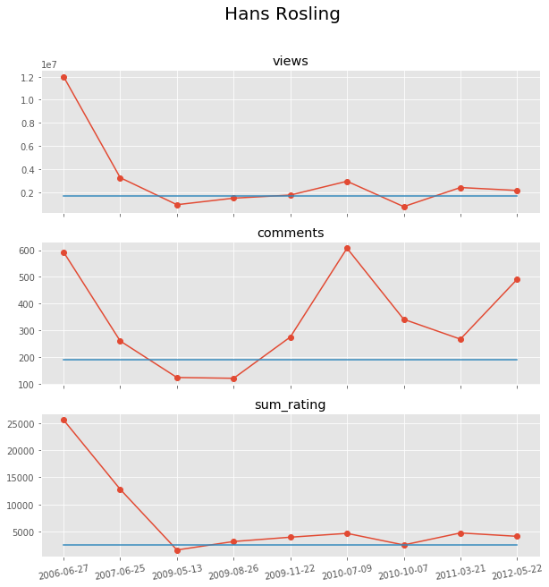

```python
Hans = Hans.sort_values('published_date')
label = Hans['published_date']
x = range(0,9)
y1 = Hans['views']
y2 = Hans['comments']
y3 = Hans['sum_rating']
plt.figure(figsize=(10,10))
plt.suptitle('Hans Rosling',fontsize=20)
ax1 = plt.subplot(311)
plt.plot(x,y1,'-o')
plt.plot(x,np.repeat(m_views,9))
plt.setp(ax1.get_xticklabels(), visible=False)
plt.title('views')
ax2 = plt.subplot(312)
plt.plot(x,y2,'-o')
plt.plot(x,np.repeat(m_comments,9))
plt.setp(ax2.get_xticklabels(), visible=False)
plt.title('comments')
ax3 = plt.subplot(313)
plt.plot(x,y3,'-o')
plt.plot(x,np.repeat(m_sum_rating,9))
plt.xticks(x,label,rotation=10)
plt.title('sum_rating')
plt.show()
```

```python
Juan = ted_main[ted_main.main_speaker == "Juan Enriquez"]
print Juan.shape
```

```
(7, 33)
```

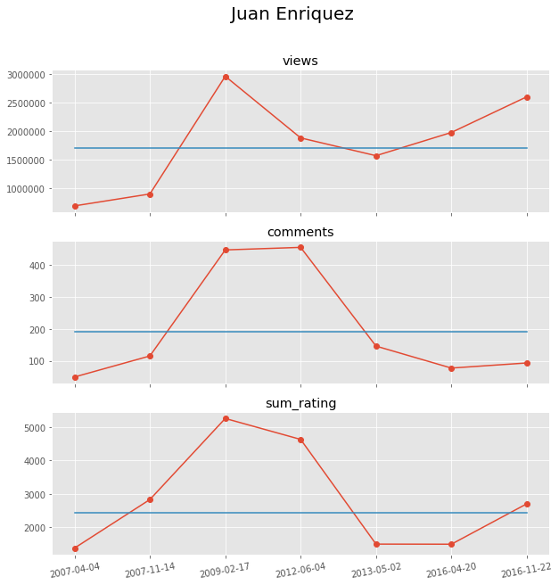

```python
Juan = Juan.sort_values('published_date')
label = Juan['published_date']
x = range(0,7)
y1 = Juan['views']
y2 = Juan['comments']
y3 = Juan['sum_rating']
plt.figure(figsize=(10,10))
plt.suptitle('Juan Enriquez',fontsize=20)
ax1 = plt.subplot(311)
plt.plot(x,y1,'-o')
plt.plot(x,np.repeat(m_views,7))
plt.setp(ax1.get_xticklabels(), visible=False)
plt.title('views')
ax2 = plt.subplot(312)
plt.plot(x,y2,'-o')
plt.plot(x,np.repeat(m_comments,7))
plt.setp(ax2.get_xticklabels(), visible=False)
plt.title('comments')
ax3 = plt.subplot(313)
plt.plot(x,y3,'-o')
plt.plot(x,np.repeat(m_sum_rating,7))
plt.xticks(x,label,rotation=10)
plt.title('sum_rating')
plt.show()
```

```python
Rives = ted_main[ted_main.main_speaker == "Rives"]
print Rives.shape
```

```
(6, 33)
```

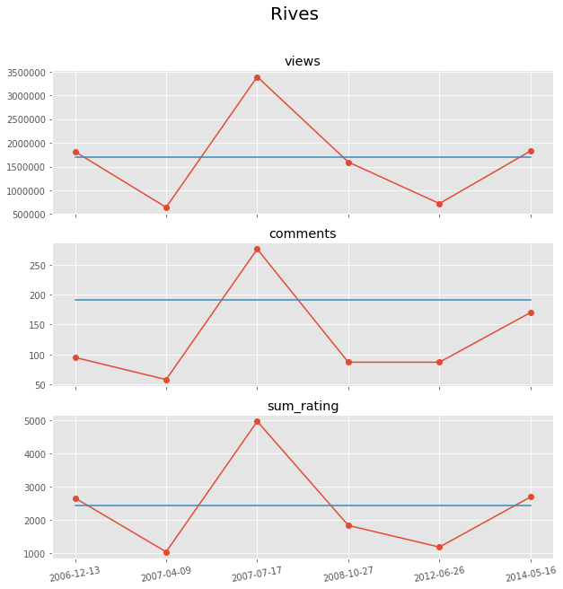

```python
Rives = Rives.sort_values('published_date')
label = Rives['published_date']
x = range(0,6)
y1 = Rives['views']
y2 = Rives['comments']
y3 = Rives['sum_rating']
plt.figure(figsize=(10,10))
plt.suptitle('Rives',fontsize=20)
ax1 = plt.subplot(311)
plt.plot(x,y1,'-o')
plt.plot(x,np.repeat(m_views,6))
plt.setp(ax1.get_xticklabels(), visible=False)
plt.title('views')
ax2 = plt.subplot(312)
plt.plot(x,y2,'-o')
plt.plot(x,np.repeat(m_comments,6))
plt.setp(ax2.get_xticklabels(), visible=False)
plt.title('comments')
ax3 = plt.subplot(313)
plt.plot(x,y3,'-o')
plt.plot(x,np.repeat(m_sum_rating,6))
plt.xticks(x,label,rotation=10)
plt.title('sum_rating')
plt.show()
```

In general, the speakers who have many speeches just have one outstanding speech with relative high number of views, comments and rating. For other speeches, the number of views, comments and ratings just similar to the average performance.

> **A famous speaker might not be able to guarantee the success of TED videos.**

## Duration of the speech

```python
# There is no strong correlation between the duration and the number of views, comments and rating
ted_main[['comments','views','sum_rating','sum_positive','sum_negative','duration']].corr()
```

|  | comments | views | sum_rating | sum_positive | sum_negative | duration |
| --- | --- | --- | --- | --- | --- | --- |
| comments | 1.000000 | 0.530939 | 0.644329 | -0.092441 | 0.045829 | 0.140694 |
| views | 0.530939 | 1.000000 | 0.865586 | 0.122957 | -0.087160 | 0.048740 |
| sum_rating | 0.644329 | 0.865586 | 1.000000 | 0.092752 | -0.058992 | 0.098311 |
| sum_positive | -0.092441 | 0.122957 | 0.092752 | 1.000000 | -0.766156 | -0.040321 |
| sum_negative | 0.045829 | -0.087160 | -0.058992 | -0.766156 | 1.000000 | 0.055718 |
| duration | 0.140694 | 0.048740 | 0.098311 | -0.040321 | 0.055718 | 1.000000 |

```
count    2550.000000
mean      826.510196
std       374.009138
min       135.000000
25%       577.000000
50%       848.000000
75%      1046.750000
max      5256.000000
Name: duration, dtype: float64
```

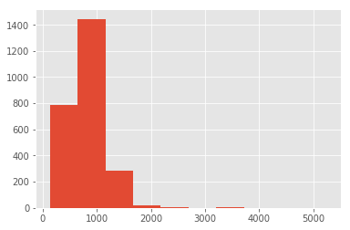

```python
print ted_main['duration'].describe()
ted_main['duration'].hist()
plt.show()
```

```python
ted_main[['main_speaker','title','duration','comments','views','sum_rating','sum_positive','sum_negative']].sort_values(by='duration',ascending=False).head(10)
```

|  | main_speaker | title | duration | comments | views | sum_rating | sum_positive | sum_negative |
| --- | --- | --- | --- | --- | --- | --- | --- | --- |
| 640 | Douglas Adams | Parrots, the universe and everything | 5256 | 101 | 473220 | 1892 | 0.897992 | 0.045455 |
| 588 | Randy Pausch | Really achieving your childhood dreams | 4587 | 124 | 564781 | 2221 | 0.847816 | 0.094102 |
| 629 | Richard Feynman | Physics is fun to imagine | 3955 | 146 | 521974 | 1600 | 0.894375 | 0.050625 |
| 2387 | Yuval Noah Harari | Nationalism vs. globalism: the new political d... | 3608 | 345 | 1514291 | 1995 | 0.797995 | 0.079699 |
| 594 | Edwidge Danticat | Stories of Haiti | 3573 | 20 | 50443 | 154 | 0.655844 | 0.240260 |
| 600 | Richard Dawkins | Growing up in the universe | 3475 | 133 | 318423 | 1086 | 0.583794 | 0.274401 |
| 580 | Michael Sandel | What's the right thing to do? | 3296 | 307 | 393459 | 1131 | 0.718833 | 0.091070 |
| 2421 | Gretchen Carlson, David Brooks | Political common ground in a polarized United ... | 2853 | 42 | 890478 | 180 | 0.633333 | 0.177778 |
| 947 | Malcolm McLaren | Authentic creativity vs. karaoke culture | 2761 | 121 | 251313 | 825 | 0.557576 | 0.324848 |
| 202 | Frank Gehry | My days as a young rebel | 2678 | 9 | 620806 | 346 | 0.543353 | 0.326590 |

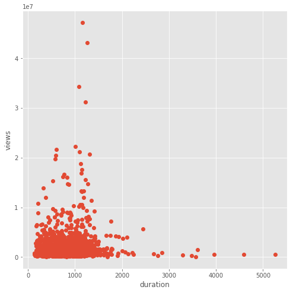

```python
# Long speeches cannot get a lot of viewers
plt.figure(figsize=(8,8))
plt.plot(ted_main.duration,ted_main.views,'o')
plt.xlabel('duration')
plt.ylabel('views')
plt.show()
```

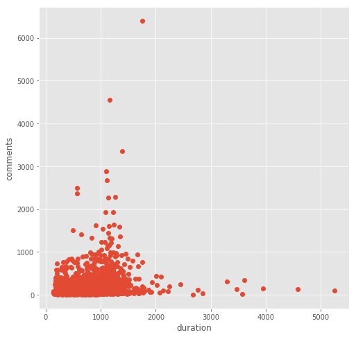

```python
# Long speeches cannot get many comments
plt.figure(figsize=(8,8))
plt.plot(ted_main.duration,ted_main.comments,'o')
plt.xlabel('duration')
plt.ylabel('comments')
plt.show()
```

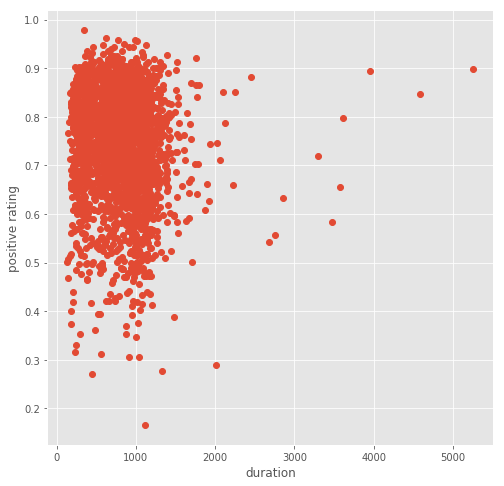

```python
plt.figure(figsize=(8,8))
plt.plot(ted_main.duration,ted_main.sum_positive,'o')
plt.xlabel('duration')
plt.ylabel('positive rating')
plt.show()
```

```
            duration  Longwinded
duration    1.000000    0.266763
Longwinded  0.266763    1.000000
```

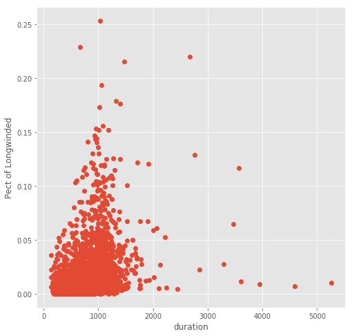

```python
# Actually, long speeches do not equal to Longwinded
# Audience might feel it is longwinded even the duration of the speech is not relatively long
print ted_main[['duration','Longwinded']].corr()
plt.figure(figsize=(8,8))
plt.plot(ted_main.duration,ted_main.Longwinded,'o')
plt.xlabel('duration')
plt.ylabel('Pect of Longwinded')
plt.show()
```

> **Duration of the speech might not be very decisive to the popularity of the TED videos**

## Theme

There are 416 tags for TED videos. We could apply text analytics tools to classify the themes of TED videos

### TFIDF

The functions to build up tfidf model for each document refer to [the article](http://brandonrose.org/clustering).

```python
# Use TFIDF to build up the matrix for each speech
from nltk.stem.snowball import SnowballStemmer
stemmer = SnowballStemmer("english")
import nltk
import re
```

```python
def tokenize_and_stem(text):
    tokens = [word for sent in nltk.sent_tokenize(text) for word in nltk.word_tokenize(sent)]
    filtered_tokens = []
    for token in tokens:
        if re.search('[a-zA-Z]', token):
            filtered_tokens.append(token)
    stems = [stemmer.stem(t) for t in filtered_tokens]
    return stems
```

```python
doc = transcript.transcript.tolist()
from sklearn.feature_extraction.text import TfidfVectorizer

tfidf_vectorizer = TfidfVectorizer(max_df=0.8, max_features=200000,
                                 min_df=0.2, stop_words='english',
                                 use_idf=True, tokenizer=tokenize_and_stem, ngram_range=(1,3))

%time tfidf_matrix = tfidf_vectorizer.fit_transform(doc) #fit the vectorizer to synopses

print(tfidf_matrix.shape)
```

```
CPU times: user 4min 17s, sys: 2.75 s, total: 4min 20s
Wall time: 4min 20s
(2467, 433)
```

```python
from sklearn.metrics.pairwise import cosine_similarity
dist = 1 - cosine_similarity(tfidf_matrix)
```

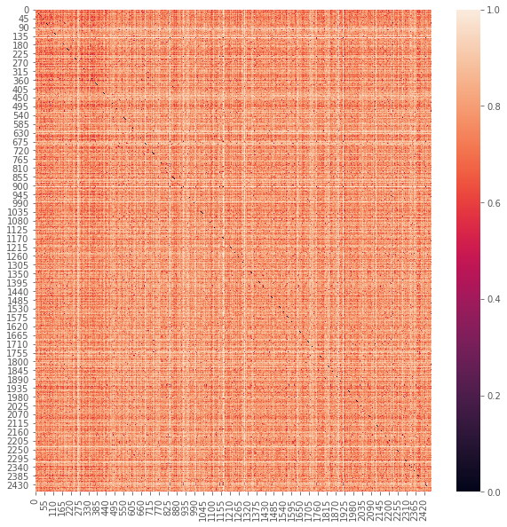

```python
plt.figure(figsize = (10,10))
sns.heatmap(dist)
plt.show()
```

```python
from sklearn.cluster import KMeans
```

```python
n_cluster = range(1,11)
all_inertia = []
for n in n_cluster:
    model = KMeans(n_clusters=n)
    %time model.fit(tfidf_matrix)
    int_value = model.inertia_
    all_inertia.append(int_value)
```

```
CPU times: user 3.46 s, sys: 9.71 ms, total: 3.47 s
Wall time: 3.48 s
CPU times: user 40.8 s, sys: 65.6 ms, total: 40.8 s
Wall time: 40.8 s
CPU times: user 40 s, sys: 39 ms, total: 40 s
Wall time: 40 s
CPU times: user 50.8 s, sys: 48.3 ms, total: 50.8 s
Wall time: 50.8 s
CPU times: user 39.7 s, sys: 43.1 ms, total: 39.7 s
Wall time: 39.7 s
CPU times: user 39.5 s, sys: 45 ms, total: 39.5 s
Wall time: 39.5 s
CPU times: user 48.8 s, sys: 53.8 ms, total: 48.8 s
Wall time: 48.8 s
CPU times: user 40.8 s, sys: 55.1 ms, total: 40.9 s
Wall time: 40.9 s
CPU times: user 49.2 s, sys: 67.5 ms, total: 49.2 s
Wall time: 49.3 s
CPU times: user 57.2 s, sys: 70.6 ms, total: 57.2 s
Wall time: 57.2 s
```

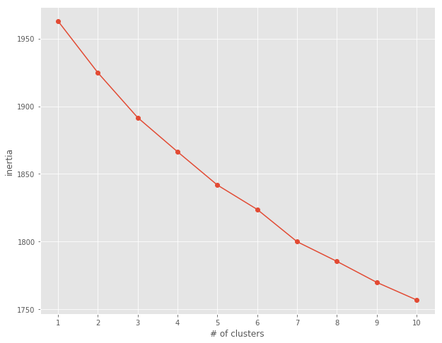

```python
# There is no significant elbow for the clusters
# Choose the number of clusters based on the number of different tags in each clusters
plt.figure(figsize=(10,8))
plt.plot(n_cluster,all_inertia,'-o')
plt.xticks(n_cluster,n_cluster)
plt.ylabel("inertia")
plt.xlabel("# of clusters")
plt.show()
```

```python
# Trying to fit the number of clusters that there are less than 300 different tags for most clusters
model = KMeans(n_clusters=9)
model.fit(tfidf_matrix)
clusters = model.labels_.tolist()
```

```python
Counter(clusters)
```

```
Counter({0: 154, 1: 670, 2: 91, 3: 671, 4: 84, 5: 229, 6: 117, 7: 85, 8: 366})
```

```python
from sklearn.externals import joblib
joblib.dump(model,'KMeans_Model.pkl')
```

```
['KMeans_Model.pkl']
```

```python
transcript['cluster'] = clusters
transcript.head()
```

|  | transcript | url | cluster |
| --- | --- | --- | --- |
| 0 | Good morning. How are you?(Laughter)It's been ... | https://www.ted.com/talks/ken_robinson_says_sc... | 0 |
| 1 | Thank you so much, Chris. And it's truly a gre... | https://www.ted.com/talks/al_gore_on_averting_... | 1 |
| 2 | (Music: "The Sound of Silence," Simon & Garfun... | https://www.ted.com/talks/david_pogue_says_sim... | 1 |
| 3 | If you're here today — and I'm very happy that... | https://www.ted.com/talks/majora_carter_s_tale... | 2 |
| 4 | About 10 years ago, I took on the task to teac... | https://www.ted.com/talks/hans_rosling_shows_t... | 8 |

```python
simp_transcript = transcript[['url','cluster']]
simp_transcript = pd.merge(simp_transcript,ted_main[['url','tags','title']],on='url',how='inner')
print simp_transcript.shape
simp_transcript.head()
```

```
(2473, 4)
```

|  | url | cluster | tags | title |
| --- | --- | --- | --- | --- |
| 0 | https://www.ted.com/talks/ken_robinson_says_sc... | 0 | [children, creativity, culture, dance, educati... | Do schools kill creativity? |
| 1 | https://www.ted.com/talks/al_gore_on_averting_... | 1 | [alternative energy, cars, climate change, cul... | Averting the climate crisis |
| 2 | https://www.ted.com/talks/david_pogue_says_sim... | 1 | [computers, entertainment, interface design, m... | Simplicity sells |
| 3 | https://www.ted.com/talks/majora_carter_s_tale... | 2 | [MacArthur grant, activism, business, cities, ... | Greening the ghetto |
| 4 | https://www.ted.com/talks/hans_rosling_shows_t... | 8 | [Africa, Asia, Google, demo, economics, global... | The best stats you've ever seen |

```python
c0_tag = [item for sub_list in simp_transcript[simp_transcript.cluster == 0]['tags'].tolist() for item in sub_list]
c1_tag = [item for sub_list in simp_transcript[simp_transcript.cluster == 1]['tags'].tolist() for item in sub_list]
c2_tag = [item for sub_list in simp_transcript[simp_transcript.cluster == 2]['tags'].tolist() for item in sub_list]
c3_tag = [item for sub_list in simp_transcript[simp_transcript.cluster == 3]['tags'].tolist() for item in sub_list]
c4_tag = [item for sub_list in simp_transcript[simp_transcript.cluster == 4]['tags'].tolist() for item in sub_list]
c5_tag = [item for sub_list in simp_transcript[simp_transcript.cluster == 5]['tags'].tolist() for item in sub_list]
c6_tag = [item for sub_list in simp_transcript[simp_transcript.cluster == 6]['tags'].tolist() for item in sub_list]
c7_tag = [item for sub_list in simp_transcript[simp_transcript.cluster == 7]['tags'].tolist() for item in sub_list]
c8_tag = [item for sub_list in simp_transcript[simp_transcript.cluster == 8]['tags'].tolist() for item in sub_list]
```

```python
c0_tag_stat = pd.Series(Counter(c0_tag))
c1_tag_stat = pd.Series(Counter(c1_tag))
c2_tag_stat = pd.Series(Counter(c2_tag))
c3_tag_stat = pd.Series(Counter(c3_tag))
c4_tag_stat = pd.Series(Counter(c4_tag))
c5_tag_stat = pd.Series(Counter(c5_tag))
c6_tag_stat = pd.Series(Counter(c6_tag))
c7_tag_stat = pd.Series(Counter(c7_tag))
c8_tag_stat = pd.Series(Counter(c8_tag))
```

```python
print c0_tag_stat.shape
print c1_tag_stat.shape
print c2_tag_stat.shape
print c3_tag_stat.shape
print c4_tag_stat.shape
print c5_tag_stat.shape
print c6_tag_stat.shape
print c7_tag_stat.shape
print c8_tag_stat.shape
```

```
(211,)
(351,)
(159,)
(354,)
(125,)
(239,)
(189,)
(171,)
(280,)
```

```python
print c0_tag_stat.nlargest(10)
print ""
print c1_tag_stat.nlargest(10)
print ""
print c2_tag_stat.nlargest(10)
print ""
print c3_tag_stat.nlargest(10)
print ""
print c4_tag_stat.nlargest(10)
print ""
print c5_tag_stat.nlargest(10)
print ""
print c6_tag_stat.nlargest(10)
print ""
print c7_tag_stat.nlargest(10)
print ""
print c8_tag_stat.nlargest(10)
```

```
education        81
children         58
global issues    37
TEDx             36
culture          36
teaching         30
technology       29
social change    28
design           23
activism         21
dtype: int64

culture          207
entertainment    157
TEDx             122
technology       106
global issues     94
science           87
communication     80
storytelling      80
art               77
humor             76
dtype: int64

cities            61
design            41
architecture      32
infrastructure    25
technology        21
urban planning    21
culture           19
global issues     17
business          13
community         13
dtype: int64

technology    333
science       217
design        199
TEDx          108
```

[output cut: 52 more lines]

```
medical research     19
health               16
dtype: int64

global issues    198
business          99
economics         89
politics          74
social change     70
technology        70
government        64
society           62
culture           57
TEDx              56
dtype: int64
```

Now we have some explainable clusters from KMeans based on the tags:

1. For Cluster 0: It is mostly related to education with tags of *education*, *children* and *teaching*
2. For Cluster 2: It is mostly related to urban planning with tags of *cities*, *design*, *architecture* and *urban planning*
3. For Cluster 3 and Cluster 5: It is mostly related to technology with biology. Tags including *biology*, *health* and *universe*
4. For Cluster 4: It is about music, with tags such as *music*, *entertainment*, *live music*, and *performance*
5. For Cluster 6: It is about feminism, with tags such as *women*, *Gender equality* and *feminism*
6. For Cluster 7: It is about neuroscience, tags including *brain*, *neuroscience* and *cognitive science*
7. For Cluster 8: It is about politics and economics, tags including *economics*, *politics* and *social change*

```python
ted_main = pd.merge(ted_main,transcript[['url','cluster']],on='url',how='inner')
print ted_main.shape
ted_main.head()
```

```
(2473, 34)
```

|  | comments | description | duration | event | film_date | languages | main_speaker | name | num_speaker | published_date | ... | Longwinded | Ingenious | Jaw-dropping | Unconvincing | Courageous | Confusing | sum_rating | sum_positive | sum_negative | cluster |
| --- | --- | --- | --- | --- | --- | --- | --- | --- | --- | --- | --- | --- | --- | --- | --- | --- | --- | --- | --- | --- | --- |
| 0 | 4553 | Sir Ken Robinson makes an entertaining and pro... | 1164 | TED2006 | 2006-02-24 | 60 | Ken Robinson | Ken Robinson: Do schools kill creativity? | 1 | 2006-06-26 | ... | 0.004124 | 0.064710 | 0.047299 | 0.003197 | 0.034662 | 0.002579 | 93850 | 0.814012 | 0.059425 | 0 |
| 1 | 265 | With the same humor and humanity he exuded in ... | 977 | TED2006 | 2006-02-24 | 43 | Al Gore | Al Gore: Averting the climate crisis | 1 | 2006-06-26 | ... | 0.038488 | 0.019074 | 0.039510 | 0.087875 | 0.047343 | 0.021117 | 2936 | 0.607970 | 0.231608 | 1 |
| 2 | 124 | New York Times columnist David Pogue takes aim... | 1286 | TED2006 | 2006-02-23 | 26 | David Pogue | David Pogue: Simplicity sells | 1 | 2006-06-26 | ... | 0.027620 | 0.064802 | 0.019122 | 0.036827 | 0.015935 | 0.009561 | 2824 | 0.723442 | 0.143414 | 1 |
| 3 | 200 | In an emotionally charged talk, MacArthur-winn... | 1116 | TED2006 | 2006-02-25 | 35 | Majora Carter | Majora Carter: Greening the ghetto | 1 | 2006-06-26 | ... | 0.014217 | 0.028165 | 0.061695 | 0.009657 | 0.203863 | 0.008584 | 3728 | 0.750268 | 0.103541 | 2 |
| 4 | 593 | You've never seen data presented like this. Wi... | 1190 | TED2006 | 2006-02-21 | 48 | Hans Rosling | Hans Rosling: The best stats you've ever seen | 1 | 2006-06-27 | ... | 0.004294 | 0.124980 | 0.145824 | 0.002615 | 0.012412 | 0.002810 | 25620 | 0.733177 | 0.157923 | 8 |

5 rows × 34 columns

```python
def ChangeName(x):
    if x == 0:
        name = 'Education'
    elif x == 2:
        name = 'Urban Planning'
    elif x == 3 or x == 5:
        name = 'Bio Tech'
    elif x == 6:
        name = 'Feminism'
    elif x == 7:
        name = 'Neuroscience'
    elif x == 8:
        name = 'Politics'
    else:
        name = 'None'
    return name
```

```python
ted_main['Theme'] = ted_main.cluster.map(ChangeName)
```

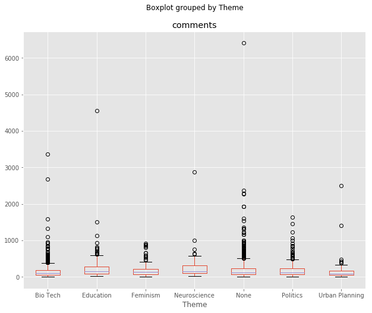

```python
ted_main.boxplot('comments',by='Theme',figsize=(10,8))
plt.show()
```

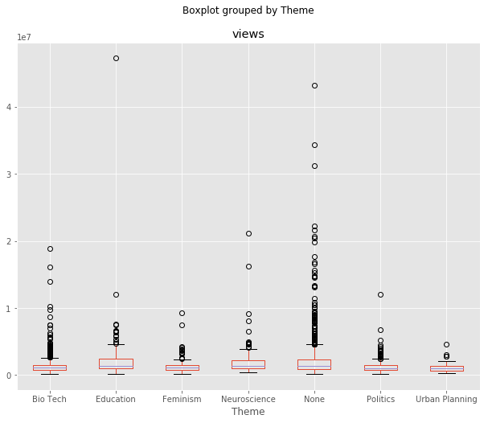

```python
ted_main.boxplot('views',by='Theme',figsize=(10,8))
plt.show()
```

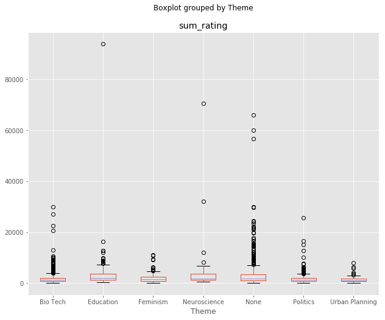

```python
ted_main.boxplot('sum_rating',by='Theme',figsize=(10,8))
plt.show()
```

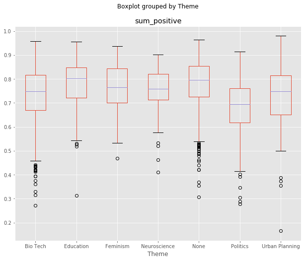

```python
ted_main.boxplot('sum_positive',by='Theme',figsize=(10,8))
plt.show()
```

```python
ted_main.groupby('Theme')[['comments','views','sum_rating','sum_positive']].mean()
```

| Theme | comments | views | sum_rating | sum_positive |
| --- | --- | --- | --- | --- |
| Bio Tech | 160.328160 | 1.372699e+06 | 1857.531042 | 0.731805 |
| Education | 258.662338 | 2.267132e+06 | 3531.415584 | 0.778404 |
| Feminism | 198.068376 | 1.419703e+06 | 2055.162393 | 0.762112 |
| Neuroscience | 248.541176 | 2.351373e+06 | 3729.800000 | 0.754283 |
| None | 218.284960 | 2.398163e+06 | 3335.444591 | 0.779157 |
| Politics | 188.688525 | 1.215465e+06 | 1777.327869 | 0.683897 |
| Urban Planning | 161.450549 | 1.107579e+06 | 1463.263736 | 0.723548 |

```python
import statsmodels.api as sm
from statsmodels.formula.api import ols

mod1 = ols('comments ~ Theme',
                data=ted_main).fit()

aov_table = sm.stats.anova_lm(mod1)
print aov_table
```

```
              df        sum_sq        mean_sq         F   PR(>F)
Theme        6.0  2.473843e+06  412307.086230  5.127168  0.00003
Residual  2466.0  1.983062e+08   80416.140849       NaN      NaN
```

```python
mod2 = ols('views ~ Theme',
                  data = ted_main).fit()
aov_table = sm.stats.anova_lm(mod2)
print aov_table
```

```
              df        sum_sq       mean_sq          F        PR(>F)
Theme        6.0  6.736242e+14  1.122707e+14  18.268653  7.372780e-21
Residual  2466.0  1.515490e+16  6.145538e+12        NaN           NaN
```

```python
mod3 = ols('sum_rating ~ Theme',
                  data = ted_main).fit()
aov_table = sm.stats.anova_lm(mod3)
print aov_table
```

```
              df        sum_sq       mean_sq         F        PR(>F)
Theme        6.0  1.502309e+09  2.503849e+08  14.38469  3.461243e-16
Residual  2466.0  4.292404e+10  1.740634e+07       NaN           NaN
```

```python
mod4 = ols('sum_positive ~ Theme',
                  data = ted_main).fit()
aov_table = sm.stats.anova_lm(mod4)
print aov_table
```

```
              df     sum_sq   mean_sq          F        PR(>F)
Theme        6.0   2.660886  0.443481  38.167456  1.569115e-44
Residual  2466.0  28.653312  0.011619        NaN           NaN
```

Based on the analysis above, we can conclude that:

1. There is a statistically significant difference for number of comments, views, rating and percentage of positive rating between different themes.
2. In general videos relate to Education and Neuroscience are more popular with more comments and number of views. In contrast, people are less interested in topics relating to Bio Tech, Politics and Urban Planning.
3. Since topics relating to politics are more controversial, the average percentage of positive rating is lower than other topics.